# Assignment 3: Sentiment Classification Reflection

```python
from pathlib import Path
from IPython.display import display, Markdown, Image
```

# 1. Training Dynamics

#### Q. Did your models show signs of overfitting or underfitting? What architectural or training changes could address this?

1. MLP
- The MLP shows mild overfitting. While the training loss continuously decreases and the training Macro F1 steadily increases, the validation loss stops improving after approximately epoch 12–15 and begins to fluctuate upward. Similarly, validation Macro F1 plateaus while training performance continues to improve. This divergence indicates that the model starts fitting training-specific patterns beyond that point.
- Mild overfitting can be reduced by increasing regularization (higher dropout and weight decay) or reducing model capacity.
2. LSTM
- The LSTM does not show signs of underfitting, as both training and validation performance steadily improve to relatively high levels. Although some fluctuations appear in the validation curve, the overall trend indicates better generalization and reduced overfitting.

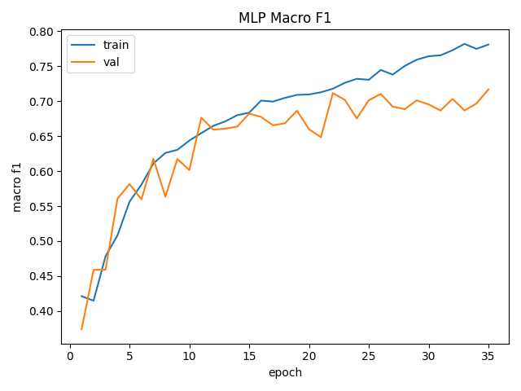

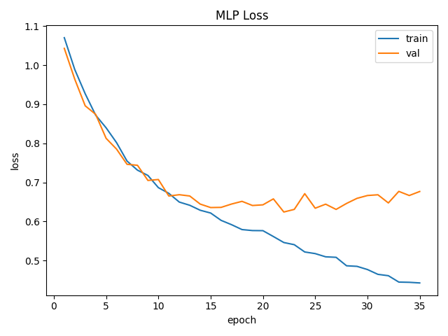

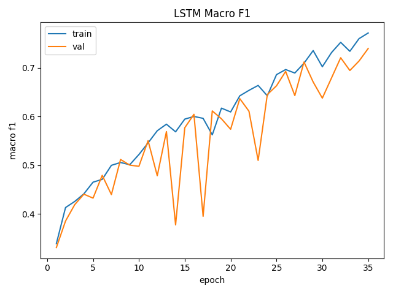

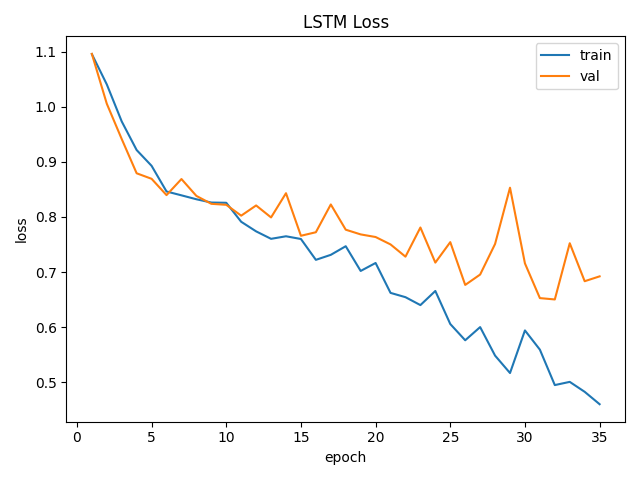

```python
display(Image(filename=str("outputs/mlp_f1_learning_curve.png"), width=400))
display(Image(filename=str("outputs/mlp_loss_learning_curve.png"), width=400))
display(Image(filename=str("outputs/lstm_f1_learning_curve.png"), width=400))
display(Image(filename=str("outputs/lstm_loss_learning_curve.png"), width=400))
```

#### Q. How did using class weights affect training stability and final performance?

- The dataset exhibits significant class imbalance, with the neutral class dominating the distribution. Without class weighting, the model would likely bias toward predicting the neutral class to maximize accuracy. Using class weights stabilized training by penalizing misclassification of minority classes more heavily. This improved Macro F1, particularly for the negative and positive classes, although it slightly increased training variance in early epochs due to stronger gradient signals from rare classes.

# 2. Model Performance and Error Analysis

#### Q. Which of your two models generalized better to the test set? Provide evidence from your metrics.

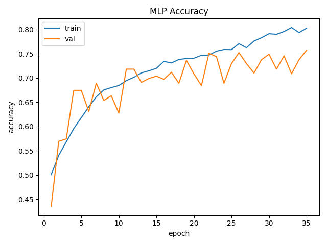

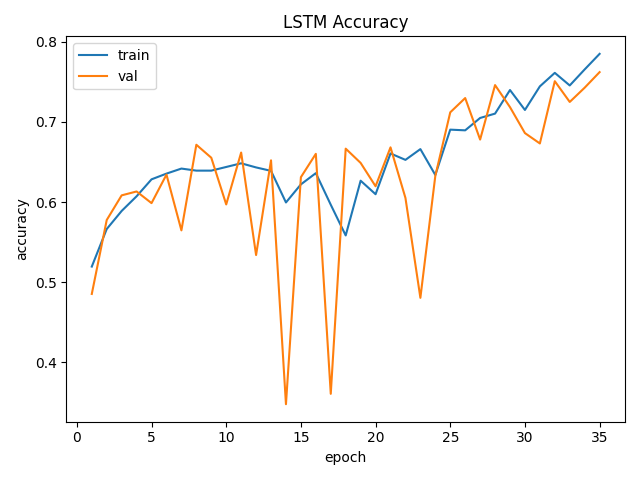

```python
display(Image(filename=str("outputs/mlp_accuracy_learning_curve.png"), width=400))
display(Image(filename=str("outputs/lstm_accuracy_learning_curve.png"), width=400))
```

#### Q. Which sentiment class was most frequently misclassified? Propose reasons for this pattern.

- In both the MLP and LSTM models, the positive class was most frequently misclassified, primarily being predicted as neutral. This pattern can be explained by the class imbalance (neutral is the dominant class). Also, financial texts frequently contain mild positive signals that are difficult to distinguish from neutral statements without deeper contextual understanding.

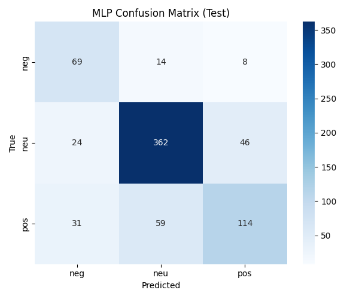

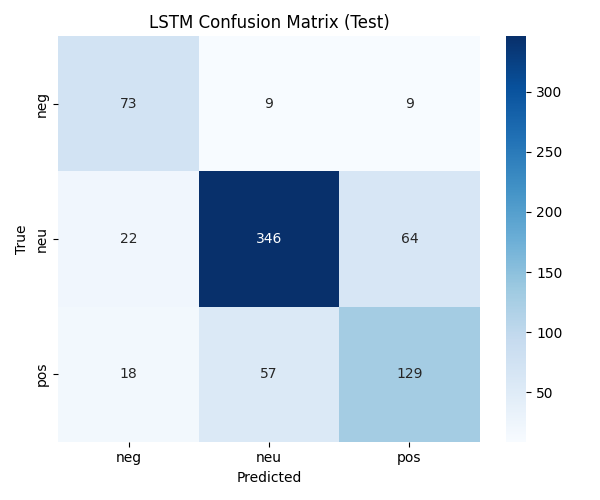

```python
display(Image(filename=str("outputs/mlp_confusion_matrix.png"), width=400))
display(Image(filename=str("outputs/lstm_confusion_matrix.png"), width=400))
```

# 3. Cross-Model Comparison

#### Q. How did mean-pooled FastText embeddings limit the MLP compared to sequence-based models?

- Mean-pooled FastText embeddings compress each sentence into a single averaged vector, which removes word order and weakens phrase-level composition. As a result, the MLP cannot capture sequence-dependent cues and mixed sentiment signals within a sentence can cancel out in the average representation.

#### Q. What advantage did the LSTM’s sequential processing provide over the MLP?

- The LSTM’s key advantage is its sequential processing: it preserves word order and can model dependencies across tokens. This allows it to capture order-sensitive cues such as negation and contrast (“not”, “but”, “although”) and to learn phrase-level patterns that are lost under mean pooling. Consistent with this, the LSTM achieved a higher test Macro F1 (0.7237 vs. 0.6966 for the MLP) and showed a smaller train–validation gap, indicating stronger generalization.

#### Q. Did fine-tuned LLMs (BERT/GPT) outperform classical baselines? Explain the performance gap in terms of pretraining and contextual representations.

- The fine-tuned LLMs (BERT, GPT) significantly outperformed the classical baselines. BERT achieved the highest test Macro F1 (~0.787), followed by GPT (~0.777), both exceeding GRU (~0.741), LSTM (~0.724), MLP (~0.697), and RNN (~0.674). This performance gap can be attributed to large-scale pretraining and contextual representations. Unlike mean-pooled FastText embeddings or sequence models trained from scratch, BERT and GPT leverage pretrained transformer architectures that encode contextual word meanings and long-range dependencies via self-attention. This allows them to better distinguish subtle sentiment differences, particularly between positive and neutral financial statements.

#### Q. Rank all six models by test performance. What architectural or representational factors explain the ranking?

1. BERT (~0.787)
2. GPT (~0.777)
3. GRU (~0.741)
4. LSTM (~0.724)
5. MLP (~0.697)
6. RNN (~0.674)
- The ranking reflects increasing representational and architectural capacity. Transformer-based models (BERT, GPT) dominate due to contextual embeddings and large-scale pretraining. GRU and LSTM outperform MLP because they preserve sequential structure and model order-sensitive patterns. Finally, the vanilla RNN performs worst among sequence models due to vanishing gradient issues and weaker long-range dependency modeling.

```
outputs/mlp_accuracy_learning_curve.png OK
```

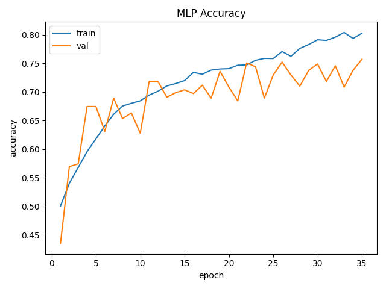

```
outputs/mlp_f1_learning_curve.png OK
```

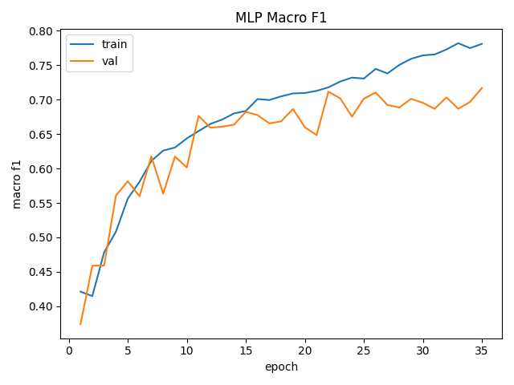

```
outputs/mlp_loss_learning_curve.png OK
```

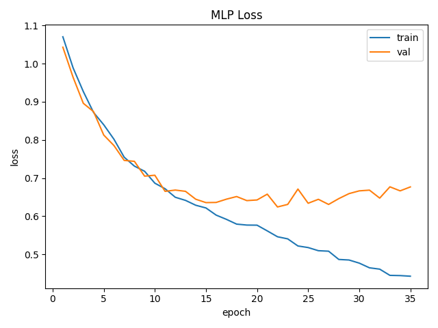

```
outputs/mlp_confusion_matrix.png OK
```

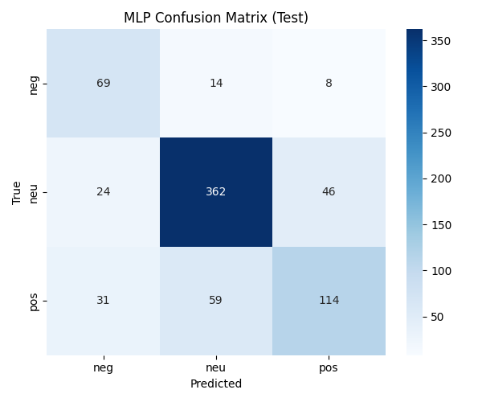

```
outputs/lstm_accuracy_learning_curve.png OK
```

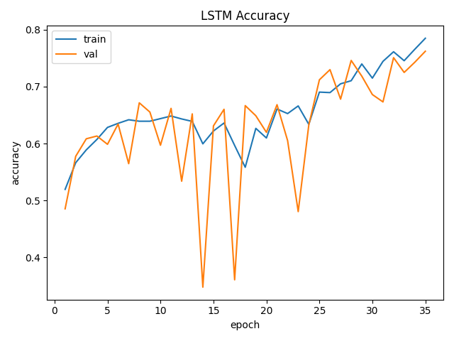

```
outputs/lstm_f1_learning_curve.png OK
```

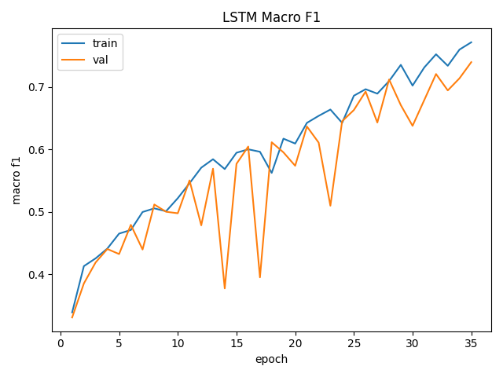

```
outputs/lstm_loss_learning_curve.png OK
```

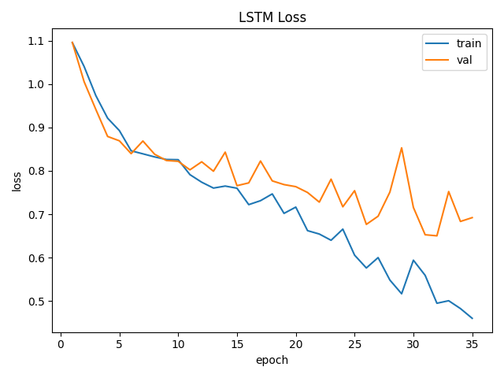

```
outputs/lstm_confusion_matrix.png OK
```

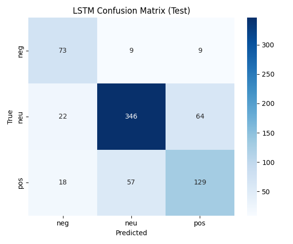

```
outputs/rnn_accuracy_learning_curve.png OK
```

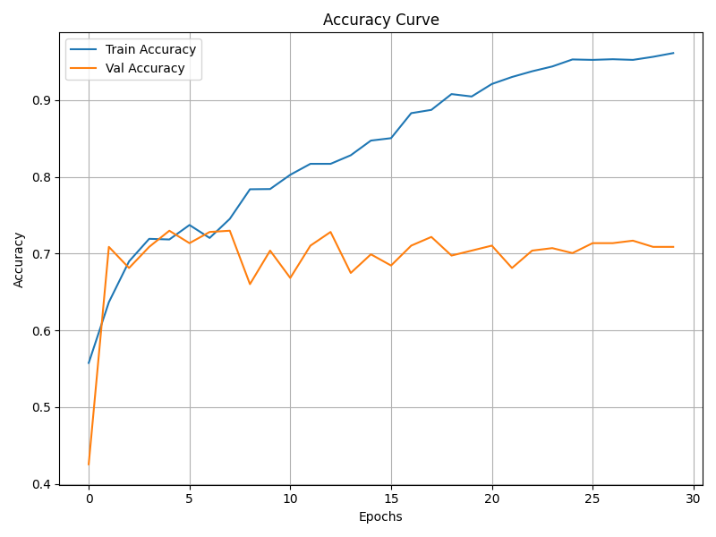

```
outputs/rnn_f1_learning_curves.png OK
```

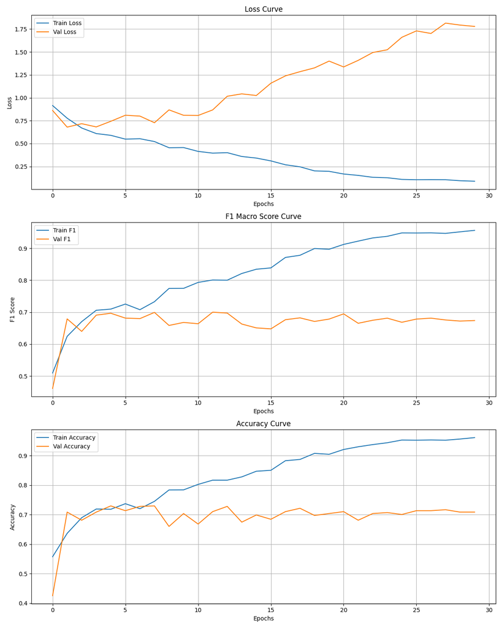

```
outputs/rnn_confusion_matrix.png OK
```

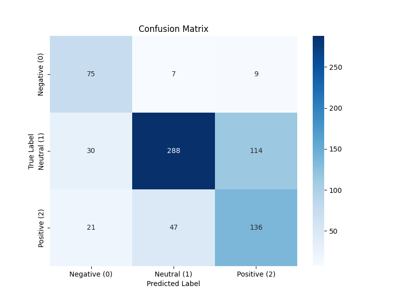

```
outputs/gru_accuracy_learning_curve.png OK
```

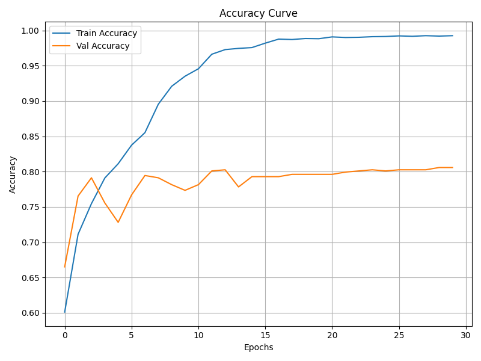

```
outputs/gru_f1_learning_curves.png OK
```

[8 more figures not shown]

```python
outdir = Path("outputs")

pngs = [
    "mlp_accuracy_learning_curve.png",
    "mlp_f1_learning_curve.png",
    "mlp_loss_learning_curve.png",
    "mlp_confusion_matrix.png",
    "lstm_accuracy_learning_curve.png",
    "lstm_f1_learning_curve.png",
    "lstm_loss_learning_curve.png",
    "lstm_confusion_matrix.png",
    "rnn_accuracy_learning_curve.png",
    "rnn_f1_learning_curves.png",
    "rnn_confusion_matrix.png",
    "gru_accuracy_learning_curve.png",
    "gru_f1_learning_curves.png",
    "gru_confusion_matrix.png",
    "bert_accuracy_learning_curve.png",
    "bert_f1_learning_curves.png",
    "bert_confusion_matrix.png",
    "gpt_accuracy_learning_curve.png",
    "gpt_f1_learning_curves.png",
    "gpt_confusion_matrix.png",
]

for p in pngs:
    fp = outdir / p
    print(fp, "OK" if fp.exists() else "MISSING")
    if fp.exists():
        display(Image(filename=str(fp)))
```

## AI Use Disclosure (Required)

If you used any AI-enabled tools (e.g., ChatGPT, GitHub Copilot, Claude, or other LLM assistants) while working on this assignment, you must disclose that use here. The goal is transparency-not punishment.

In your disclosure, briefly include: - **Tool(s) used:** (name + version if known) - **How you used them:** (e.g., concept explanation, debugging, drafting code, rewriting text) - **What you verified yourself:** (e.g., reran the notebook, checked outputs/plots, checked shapes, read documentation) - **What you did *not* use AI for (if applicable):** (optional)

You are responsible for the correctness of your submission, even if AI suggested code or explanations.

#### Write your disclosure here.

- **Tool(s) used:** ChatGPT 5.2
- **How you used them:** Mainly for Debugging and wording edits for written responses.
- **What you verified yourself:** Checked outputs, Interpretation the results.